## Peer Assesment 2

## The Natural events that cause the most harm in Health and Economy.

### Synopsis

Natural dissasters are really costly in money, injuries and human lifes. We want to analyze which of these are the ones that cause the worst impact.

### Data Processing

Explanation of how the data was processed for this study.

Loading the data.

```r
StormData = read.csv("repdata-data-StormData.csv")
```

Across the United States, which types of events are most harmful with respect to population health?

I’ll measure the population health in terms of the injuries and fatalities.I will asume that the larger these averages per event The most harmful. To try to solve the previous question I’ll calculate the average number of injuries and fatalities per event.

```r
fatalities_events = aggregate(FATALITIES~EVTYPE,data=StormData,mean)

injuries_events = aggregate(INJURIES~EVTYPE,data=StormData,mean)
```

After merging these sets I will assume an injury and a fatality are equaly bad, hence I’m ordering and displaying the top 10 events that cause the most of both. These are the top 10 sources of Fatalities and Injuries:

```r
all_health = merge(fatalities_events,injuries_events)

all_health_order = all_health[with(all_health, order(-(FATALITIES+INJURIES))),]

injuries_order = all_health[with(all_health, order(-INJURIES)),]

fatalities_order = all_health[with(all_health, order(-FATALITIES)),]

top_health = head(all_health_order,10)
top_health
```

```
##                         EVTYPE FATALITIES INJURIES
## 277                  Heat Wave     0.0000    70.00
## 851      TROPICAL STORM GORDON     8.0000    43.00
## 954                 WILD FIRES     0.7500    37.50
## 821              THUNDERSTORMW     0.0000    27.00
## 842 TORNADOES, TSTM WIND, HAIL    25.0000     0.00
## 366         HIGH WIND AND SEAS     3.0000    20.00
## 279          HEAT WAVE DROUGHT     4.0000    15.00
## 656            SNOW/HIGH WINDS     0.0000    18.00
## 973    WINTER STORM HIGH WINDS     1.0000    15.00
## 411          HURRICANE/TYPHOON     0.7273    14.49
```

```
##                         EVTYPE FATALITIES INJURIES
## 277                  Heat Wave       0.00     70.0
## 851      TROPICAL STORM GORDON       8.00     43.0
## 954                 WILD FIRES       0.75     37.5
## 821              THUNDERSTORMW       0.00     27.0
## 842 TORNADOES, TSTM WIND, HAIL      25.00      0.0
## 366         HIGH WIND AND SEAS       3.00     20.0
```

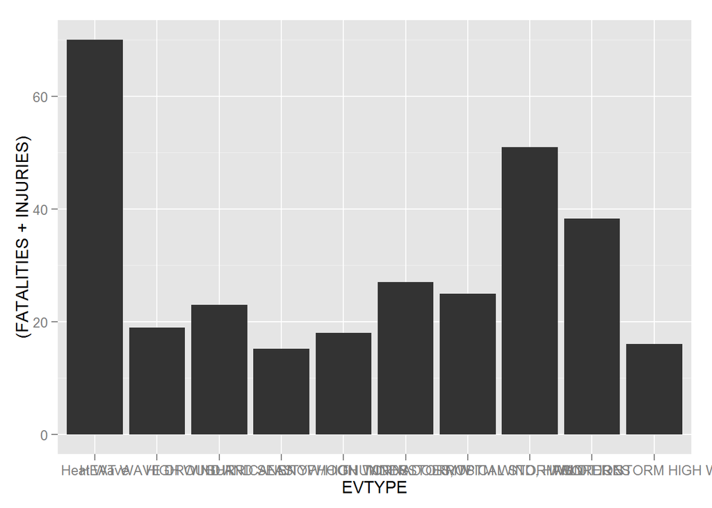

```r
library(ggplot2)
ggplot(data=top_health, aes(x=EVTYPE, y=(FATALITIES+INJURIES))) + geom_bar(stat="identity")
```

Across the United States, which types of events have the greatest economic consequences?

I’ll measure the economic consequences in terms of the damage caused to crops and properties. I will asume that the larger these averages per event The most economical consequences they had . To try to solve the previous question I’ll calculate the average number of damages per event.

```r
cropdmg_events = aggregate(CROPDMG~EVTYPE,data=StormData,mean)

propdmg_events = aggregate(PROPDMG~EVTYPE,data=StormData,mean)
```

Both of these sets are in the same unit (USD) because of this they can be compared equally. I’m ordering and displaying the top 10 events that cause economical impact. These are the top 10 sources of Economical Impact:

```r
all_economical = merge(cropdmg_events,propdmg_events)

all_economical_order = all_economical[with(all_economical, order(-(CROPDMG+PROPDMG))),]

top_economical = head(all_economical_order,10)
top_economical
```

```
##                     EVTYPE CROPDMG PROPDMG
## 851  TROPICAL STORM GORDON     500     500
## 52         COASTAL EROSION       0     766
## 291   HEAVY RAIN AND FLOOD       0     600
## 589 RIVER AND STREAM FLOOD       0     600
## 445              Landslump       0     570
## 118  DUST STORM/HIGH WINDS     500      50
## 392        HIGH WINDS/COLD     401     122
## 190           FOREST FIRES     500       5
## 38   BLIZZARD/WINTER STORM       0     500
## 158           FLASH FLOOD/       0     500
```

```
##                     EVTYPE CROPDMG PROPDMG
## 851  TROPICAL STORM GORDON     500     500
## 52         COASTAL EROSION       0     766
## 291   HEAVY RAIN AND FLOOD       0     600
## 589 RIVER AND STREAM FLOOD       0     600
## 445              Landslump       0     570
## 118  DUST STORM/HIGH WINDS     500      50
```

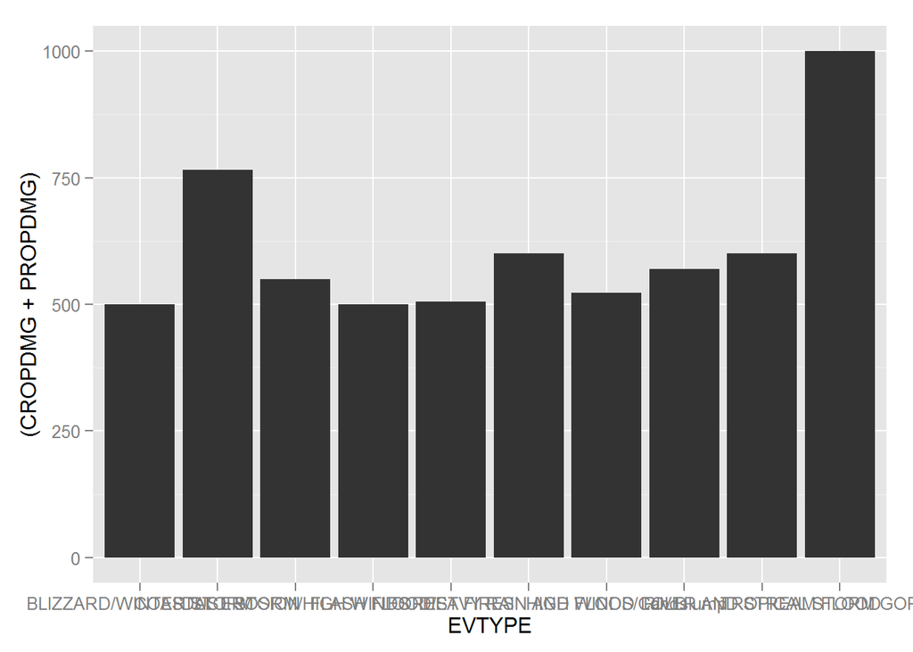

```r
library(ggplot2)
ggplot(data=top_economical, aes(x=EVTYPE, y=(CROPDMG+PROPDMG))) + geom_bar(stat="identity")
```

### Results

The Most harmful events to Health are Heat Waves, Tropical Storm Gordon, Wildfires, Thunderstorms, Tornadoes and High Wind and Seas. The most deadly being Tornadoes, and the most Injures with Heat Waves.

If We had to pick a single worst event with economicals and health implications it’d be Tropical Storm Gordon.